# Data Mining Course Project Data Science Job Salaries

REMA ALSHAREF 442200419  
RUBA ALBNHAR 442200904  
MARYAM ALRAWYAH 442201849

Goal of collecting this Dataset Understanding the factors influencing salaries in the rapidly expanding field of data science is essential for employees, job seekers, and organizations. By analyzing various job and employee characteristics such as experience level, employment type, work years, job title, salary, remote work ratio, company location, and company size, we aim to develop a predictive model that can help individuals and businesses make informed decisions and stay updated on market trends. This will enable organizations to establish fair and competitive salary ranges and facilitate meaningful discussions during the hiring process.”  
The source of the dataset:  
https://www.kaggle.com/datasets/ruchi798/data-science-job-salaries

Work_year : The year the salary was paid.

experience_level : The experience level in the job during the year with the following possible values: EN Entry-level / Junior MI Mid-level / Intermediate SE Senior-level / Expert EX Executive-level / Director

employment_type : The type of employement for the role: PT Part-time FT Full-time CT Contract FL Freelance

job_title : The role worked in during the year.

salary: The total gross salary amount paid.

salary_currency: The currency of the salary paid as an ISO 4217 currency code

salary_in_usd : The salary in USD (FX rate divided by avg. USD rate for the respective year

employee_residence: Employee’s primary country of residence in during the work year.

remote_ratio: The overall amount of work done remotely, possible values are as follows: 0 No remote work (less than 20%) 50 Partially remote 100 Fully remote (more than 80%)

company_location: The country of the employer’s main office or contracting branch as an ISO 3166 country code.

company_size: The average number of people that worked for the company during the year: S less than 50 employees (small) M 50 to 250 employees (medium) L more than 250 employees (large)

```r
# importing dataset
dataset = read.csv('ds_salaries.csv')
print(dataset)
```

| X | work_year | experience_level | employment_type | job_title | salary | salary_currency | salary_in_usd | employee_residence | remote_ratio | company_location | company_size |
| --- | --- | --- | --- | --- | --- | --- | --- | --- | --- | --- | --- |
| 0 | 2020 | MI | FT | Data Scientist | 70000 | EUR | 79833 | DE | 0 | DE | L |
| 1 | 2020 | SE | FT | Machine Learning Scientist | 260000 | USD | 260000 | JP | 0 | JP | S |
| 2 | 2020 | SE | FT | Big Data Engineer | 85000 | GBP | 109024 | GB | 50 | GB | M |
| 3 | 2020 | MI | FT | Product Data Analyst | 20000 | USD | 20000 | HN | 0 | HN | S |
| 4 | 2020 | SE | FT | Machine Learning Engineer | 150000 | USD | 150000 | US | 50 | US | L |
| 5 | 2020 | EN | FT | Data Analyst | 72000 | USD | 72000 | US | 100 | US | L |
| 6 | 2020 | SE | FT | Lead Data Scientist | 190000 | USD | 190000 | US | 100 | US | S |
| 7 | 2020 | MI | FT | Data Scientist | 11000000 | HUF | 35735 | HU | 50 | HU | L |
| 8 | 2020 | MI | FT | Business Data Analyst | 135000 | USD | 135000 | US | 100 | US | L |
| 9 | 2020 | SE | FT | Lead Data Engineer | 125000 | USD | 125000 | NZ | 50 | NZ | S |

[output cut: 597 more lines]

```r
NA
```

calculates the total number of missing values in the dataset ,and nothing any missing values

```r
# missing data
sum(is.na(dataset))
```

```
[1] 0
```

Statical measures By using the summary() function on each attribute, you can obtain a summary of the values and their distributions, helping you gain a better understanding of the dataset.

```r
#statical measurmwnt

summary(dataset$work_year)
```

```
   Min. 1st Qu.  Median    Mean 3rd Qu.    Max.
   2020    2021    2022    2021    2022    2022
```

```r
summary(dataset$experience_level)
```

```
   Length     Class      Mode
      607 character character
```

```r
summary(dataset$employment_type)
```

```
   Length     Class      Mode
      607 character character
```

```r
summary(dataset$salary)
```

```
    Min.  1st Qu.   Median     Mean  3rd Qu.     Max.
    4000    70000   115000   324000   165000 30400000
```

```r
summary(dataset$salary_in_usd)
```

```
   Min. 1st Qu.  Median    Mean 3rd Qu.    Max.
   2859   62726  101570  112298  150000  600000
```

```r
summary(dataset$remote_ratio)
```

```
   Min. 1st Qu.  Median    Mean 3rd Qu.    Max.
   0.00   50.00  100.00   70.92  100.00  100.00
```

```r
summary(dataset$company_location)
```

```
   Length     Class      Mode
      607 character character
```

```r
summary(dataset$company_size)
```

```
   Length     Class      Mode
      607 character character
```

By using this code, these attribute will be transformed into a numeric value . encoding will be easier to deal with attributes and in calculation.

```r
#encoding rempte_ratio
dataset$remote_ratio = factor(dataset$remote_ratio,
                              levels= c("0","50","100"),
                              labels=c(0,0.5,1))

#encoding experience_level


dataset$experience_level <- factor(dataset$experience_level,
                              levels = c("EN","MI","SE","EX"),
                              labels= c(1 , 2 , 3 , 4))



#encoding employment_type
dataset$employment_type = factor(dataset$employment_type,
                                  levels= c('PT','FT','CT','FL'),
                                 labels=c(1,2,3,4))


#encoding company_size
dataset$company_size = factor(dataset$company_size,
                                  levels= c('S','M','L'),
                                  labels=c(1,2,3))
print(dataset)
```

| X | work_year | experience_level | employment_type | job_title | salary | salary_currency | salary_in_usd | employee_residence | remote_ratio | company_location | company_size |
| --- | --- | --- | --- | --- | --- | --- | --- | --- | --- | --- | --- |
| 0 | 2020 | 2 | 2 | Data Scientist | 70000 | EUR | 79833 | DE | 0 | DE | 3 |
| 1 | 2020 | 3 | 2 | Machine Learning Scientist | 260000 | USD | 260000 | JP | 0 | JP | 1 |
| 2 | 2020 | 3 | 2 | Big Data Engineer | 85000 | GBP | 109024 | GB | 0.5 | GB | 2 |
| 3 | 2020 | 2 | 2 | Product Data Analyst | 20000 | USD | 20000 | HN | 0 | HN | 1 |
| 4 | 2020 | 3 | 2 | Machine Learning Engineer | 150000 | USD | 150000 | US | 0.5 | US | 3 |
| 5 | 2020 | 1 | 2 | Data Analyst | 72000 | USD | 72000 | US | 1 | US | 3 |
| 6 | 2020 | 3 | 2 | Lead Data Scientist | 190000 | USD | 190000 | US | 1 | US | 1 |
| 7 | 2020 | 2 | 2 | Data Scientist | 11000000 | HUF | 35735 | HU | 0.5 | HU | 3 |
| 8 | 2020 | 2 | 2 | Business Data Analyst | 135000 | USD | 135000 | US | 1 | US | 3 |
| 9 | 2020 | 3 | 2 | Lead Data Engineer | 125000 | USD | 125000 | NZ | 0.5 | NZ | 1 |

[output cut: 597 more lines]

we’ve done dimensionality reduction for the ( SALARY , SALARY CURRENCY, EMPLOYEE RESIDENCE ) Because it causes redundant data in our dataset, and doesn’t provide us good information for our label which is (understanding the factors influencing salaries in Data science field).

```r
#dimensionality reduction
dataset<-subset(dataset,select=-c(salary))

dataset<-subset(dataset,select=-c(salary_currency))

dataset<-subset(dataset,select=-c(employee_residence))
print(dataset)
```

|  | X | work_year | experience_level | employment_type | job_title | salary_in_usd | remote_ratio | company_location | company_size |
| --- | --- | --- | --- | --- | --- | --- | --- | --- | --- |
| 1 | 0 | 2020 | 2 | 2 | Data Scientist | 79833 | 0 | DE | 3 |
| 2 | 1 | 2020 | 3 | 2 | Machine Learning Scientist | 260000 | 0 | JP | 1 |
| 3 | 2 | 2020 | 3 | 2 | Big Data Engineer | 109024 | 0.5 | GB | 2 |
| 4 | 3 | 2020 | 2 | 2 | Product Data Analyst | 20000 | 0 | HN | 1 |
| 5 | 4 | 2020 | 3 | 2 | Machine Learning Engineer | 150000 | 0.5 | US | 3 |
| 6 | 5 | 2020 | 1 | 2 | Data Analyst | 72000 | 1 | US | 3 |
| 7 | 6 | 2020 | 3 | 2 | Lead Data Scientist | 190000 | 1 | US | 1 |
| 8 | 7 | 2020 | 2 | 2 | Data Scientist | 35735 | 0.5 | HU | 3 |
| 9 | 8 | 2020 | 2 | 2 | Business Data Analyst | 135000 | 1 | US | 3 |
| 10 | 9 | 2020 | 3 | 2 | Lead Data Engineer | 125000 | 0.5 | NZ | 1 |

[output cut: 597 more lines]

```r
#finding outliers


boxplot.stats(dataset$salary_in_usd)$out
```

```
 [1] 325000 450000 412000 450000 423000 416000 600000 324000 380000 405000
```

```r
#normlization

normalize=function (x) {return ((x-min(x))/ (max(x)))}
dataset $salary_in_usd=normalize(dataset $salary_in_usd)
print(dataset)
```

|  | X | work_year | experience_level | employment_type | job_title | salary_in_usd | remote_ratio | company_location | company_size |
| --- | --- | --- | --- | --- | --- | --- | --- | --- | --- |
| 1 | 0 | 2020 | 2 | 2 | Data Scientist | 0.128290000 | 0 | DE | 3 |
| 2 | 1 | 2020 | 3 | 2 | Machine Learning Scientist | 0.428568333 | 0 | JP | 1 |
| 3 | 2 | 2020 | 3 | 2 | Big Data Engineer | 0.176941667 | 0.5 | GB | 2 |
| 4 | 3 | 2020 | 2 | 2 | Product Data Analyst | 0.028568333 | 0 | HN | 1 |
| 5 | 4 | 2020 | 3 | 2 | Machine Learning Engineer | 0.245235000 | 0.5 | US | 3 |
| 6 | 5 | 2020 | 1 | 2 | Data Analyst | 0.115235000 | 1 | US | 3 |
| 7 | 6 | 2020 | 3 | 2 | Lead Data Scientist | 0.311901667 | 1 | US | 1 |
| 8 | 7 | 2020 | 2 | 2 | Data Scientist | 0.054793333 | 0.5 | HU | 3 |
| 9 | 8 | 2020 | 2 | 2 | Business Data Analyst | 0.220235000 | 1 | US | 3 |
| 10 | 9 | 2020 | 3 | 2 | Lead Data Engineer | 0.203568333 | 0.5 | NZ | 1 |

[output cut: 597 more lines]

the outliers important for our dataset because we want to study what makes the salaries higher for data Scientists.

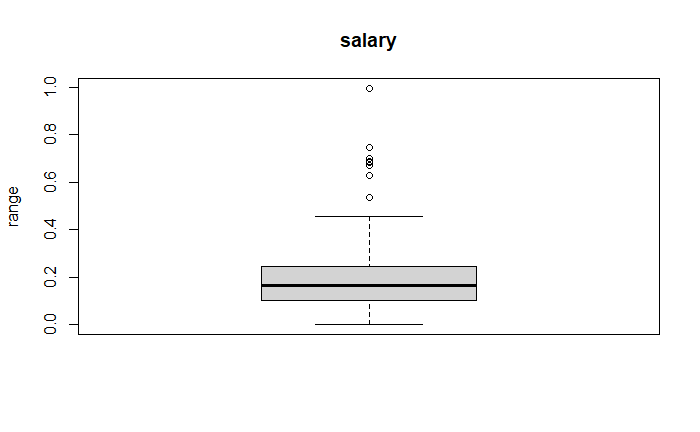

```r
# boxblot
boxplot(dataset$salary_in_usd , main= "salary" , ylab="range")
```

The year 2022 represents %52.4 of the results which means it’s the largest number recorded our dataset.

```r
#bie chart
install.packages("dplyr") # install only one time then put this command as comment after installation
```

[output not shown]

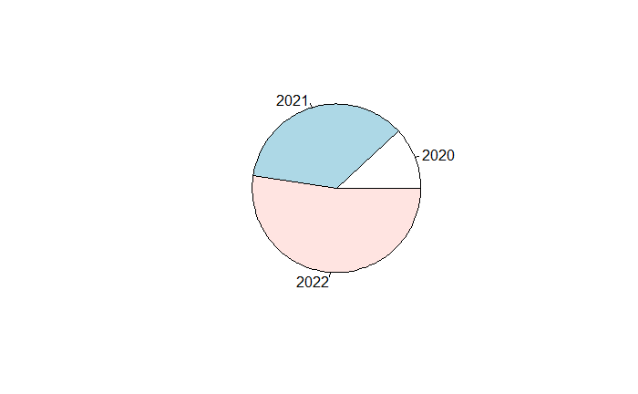

```r
library(dplyr)

dataset$work_year %>% table() %>% pie()
```

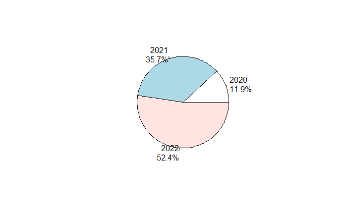

```r
tab <- dataset$work_year %>% table()
precentages <- tab %>% prop.table() %>% round(3) * 100
txt <- paste0(names(tab), '\n', precentages, '%') # text on chart
pie(tab, labels=txt) # plot pie chart
```

In the job title, the largest percentage of the highest salaries was in data analysis and data science fields.

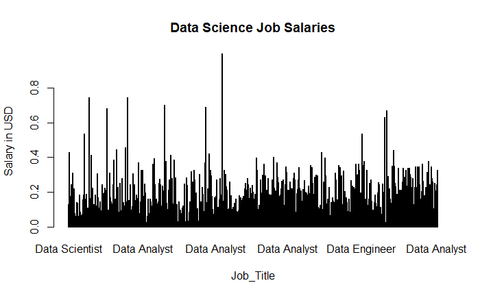

```r
# Extract the attribute values
categories <- dataset$job_title
values <- dataset$salary_in_usd

# Create the bar chart
barplot(values, names.arg = categories, xlab = "Job_Title", ylab = "Salary in USD", main = "Data Science Job Salaries")
```

[figure not shown]

```r
# Rotate x-axis labels for better readability
par(las = 2)



# Create the scatter plot for Experience Level vs. Salary (USD)
library(ggplot2)


ggplot(dataset, aes(x = experience_level, y = salary_in_usd)) +
  geom_point() +
  labs(x = "Experience Level", y = "Salary (USD)") +
  ggtitle("Experience Level vs. Salary (USD)") +
  theme_minimal()
```

[figure not shown]

```r
# Create a grouped bar chart
ggplot(dataset, aes(x = dataset$employment_type, y = dataset$remote_ratio, fill = dataset$salary_in_usd)) +
  geom_bar(stat = "identity", position = "dodge") +
  xlab("employment_type") +
  ylab("remote_ratio") +
  ggtitle("Grouped Bar Chart with Attribute 3") +
  theme_bw()
```

[figure not shown]

```r
# Create a grouped bar chart
ggplot(dataset, aes(x = dataset$company_size, y = dataset$experience_level, fill = dataset$salary_in_usd)) +
  geom_bar(stat = "identity", position = "dodge") +
  xlab("cop_size") +
  ylab("exp_level") +
  ggtitle("Grouped Bar Chart with Attribute 3") +
  theme_bw()
```